# Multivariate Data Analysis - chapter 06

# 6. 정준상관분석

## 1. 정준상관분석이란?

- 상관계수 : 두 연속형 변수 X,Y의 선형관계의 밀접도를 구하는 통계량ㅇ
- 몇 개의 변수들로 이루어진 집단들 사이의 연관성을 알고자 하는 경우
- 예> 학생들의 신체조건과 운동능력 사이의 연관성 측정
  - 측정변수
    - 신체조건 변수( $X_1$ = 키, $X_2$ = 앉은키, $X_3$ = 가슴둘레)
    - 운동능력 변수( $Y_1$ =100m 달리기, $Y_2$ = 멀리뛰기, $Y_3$ = 높이뛰기, $Y_4$ = 공던지기)
- 물음: 신체조건과 운동능력 사이의 연관성을 어떻게 구할 수 있을 까?
- 접근방법 : 이와 같이 여러 개의 변수로 구성된 X 변수드로가 여러개의 변수로 이루어진 Y 변수들 사이의 연관성을 구하는 방법은 X 변수들의 선형결합으로 이루어진 변수와 Y 변수들의 선형결합으로 이루어진 변수들을 만들어 이들의 상관계수로 두 집단 사이의 상관성을 구함
  - 이와 같이 몇 개 변수들이 집단으로 관측된 두 집단 사이의 연관성(상관성)을 구하는 통계적분석방법이 정준상관분석임.

## 2. 정준상관분석모형

- 정준상관분석모형 : 두 변수집단 사이의 상관성을 구하기 위한 두 변수 집단의 선형결합 모형을 말함
- 학생들의 신체조건과 운동능력 사이의 연관성을 측정하기 위한 예에서 : 세 가지 신체조건과 네 가지 운동능력에서 변수집단 ( $X_1, X_2, X_3$ )와 ( $Y_1, Y_2, Y_3, Y_4$ )의 선형결합변수를 각각 W, V라 할때 다음을 구한 후에 변수 W와 V의 상관계수를 구함

  $$W = a_1 X_1 + a_2 X_2 + a_3 X_3 \\V = b_1 Y_1 + b_2 Y_2 + b_3 Y_3 + b_4
  Y_4$$
- (문1) 두 상관계수 ( $a_1, a_2, a_3$ )와 ( $b_1, b_2, b_3, b_4$ )는 어떻게 구하는가?
- (문2) $W$ 와 $V$ 상관계수 값의 크기는 얼마인가?

## 3. 정준상관분석과정

### 단계 1: X 변수들과 Y 변수들의 선형식을

$$W_1 = a_{11} X_1 + a_{12} X_2 + a_{13} X_3 \\V_1 = b_{11} Y_1 + b_{12}
Y_2 + b_{13} Y_3 + b_{14} Y_4$$

라 하고 $W_1$ 과 $V_1$ 의 상관계수를 $r_1$ 이라 함. 먼저 두 변수 $W_1$ 과 $V_1$ 의 상관계수 $r_1$ 이 최대가 되도록 선형계수 ( $a_{11}, a_{12}, a_{13}$ )와 ( $b_{11}, b_{12}, b_{13}, b_{14}$ ) 를 추정

### 단계 2: 다음 단계는 다른 선형결합 변수

$W_2 = a_{21} X_1 + a_{22} X_2 + a_{23} X_3 \\V_2 = b_{21} Y_1 + b_{22} Y_2 + b_{23} Y_3 + b_{24} Y_4$ 가 $W_1$, $V_1$ 과 각각 서로 독립이면서 $W_2$ 와 $V_2$ 의 상관계수 $r_2$ 가 최대가 되도록 하는 계수들을 찾음.

- 이와 같은 방법으로 새로운 선형 결합변수를 찾아나가는 과정이 정준상관분석 과정임
- 일반적으로 두 변수집단의 선형결합 쌍의 수는 크기가 작은 변수집단의 변수의 수가 됨.

## 4. R을 이용한 정준상관분석

`예` 판매사원 50명을 대상으로 조사한 적성시험과 판매실적 자료가 <자료 6.1>과 같다. 적성시험은 4개 변수가 측정되고 판매실적은 3개 변수가 관측되었다.

자료 6.1

| 항목 | 변수 | 의미 |
| --- | --- | --- |
| 사원 | ID | 판매사원 번호 |
| 적성 시험 | $X_1\\ X_2 \\ X_3 \\ X_4$ | 창의력 시험점수 조직적사고력 시험점수 추리력 시험점수 수리 시험점수 |
| 판매 실적 | $Y_1\\Y_2\\Y_3$ | 판매 성장률 판매 이익률 새로운 고객 판매율 |

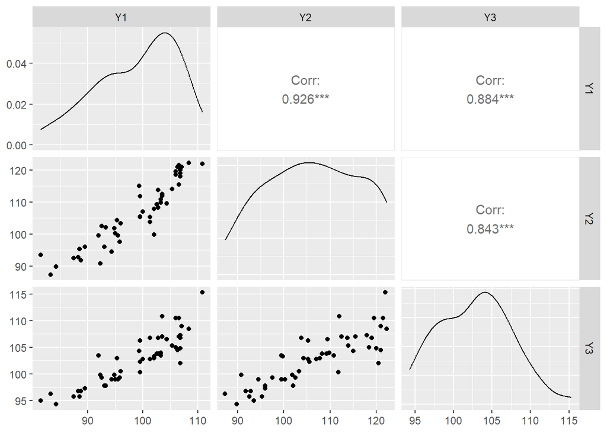

```r
sales = read.csv("./data/sales.csv")

#산점도 및 상관계수 구하기
library(ggplot2)
library(GGally)
library(CCA)
exam = sales[, c(2:5)]
perform = sales[, c(6:8)]

# scatterplots and corr. of exam
ggpairs(perform)
```

```r
matcor(exam, perform)
```

```
## $Xcor
##           X1        X2        X3        X4
## X1 1.0000000 0.5920105 0.1436729 0.4137107
## X2 0.5920105 1.0000000 0.3859502 0.5745533
## X3 0.1436729 0.3859502 1.0000000 0.5663721
## X4 0.4137107 0.5745533 0.5663721 1.0000000
##
## $Ycor
##           Y1        Y2        Y3
## Y1 1.0000000 0.9260758 0.8840023
## Y2 0.9260758 1.0000000 0.8425232
## Y3 0.8840023 0.8425232 1.0000000
##
## $XYcor
##           X1        X2        X3        X4        Y1        Y2        Y3
## X1 1.0000000 0.5920105 0.1436729 0.4137107 0.5712660 0.5438665 0.6971657
## X2 0.5920105 1.0000000 0.3859502 0.5745533 0.7080738 0.7459097 0.6374712
## X3 0.1436729 0.3859502 1.0000000 0.5663721 0.6744073 0.4653880 0.6410886
## X4 0.4137107 0.5745533 0.5663721 1.0000000 0.9273116 0.9442960 0.8525682
## Y1 0.5712660 0.7080738 0.6744073 0.9273116 1.0000000 0.9260758 0.8840023
## Y2 0.5438665 0.7459097 0.4653880 0.9442960 0.9260758 1.0000000 0.8425232
## Y3 0.6971657 0.6374712 0.6410886 0.8525682 0.8840023 0.8425232 1.0000000
```

```r
# 정준상관분석 실행하기
cano_result = cc(exam, perform)
names(cano_result)
```

```
## [1] "cor"    "names"  "xcoef"  "ycoef"  "scores"
```

```r
cano_result$cor
```

```
## [1] 0.9941528 0.8736326 0.3818977
```

```r
# 정준상관분석 계수
round(cano_result$xcoef, 3)
```

```
##      [,1]   [,2]   [,3]
## X1 -0.068  0.192  0.249
## X2 -0.033 -0.201 -0.145
## X3 -0.086  0.501 -0.273
## X4 -0.063 -0.068  0.010
```

```r
round(cano_result$ycoef, 3)
```

```
##      [,1]   [,2]   [,3]
## Y1 -0.061  0.177 -0.376
## Y2 -0.023 -0.242  0.102
## Y3 -0.075  0.237  0.385
```

```r
# 정준상관 점수
cano_result$scores
```

```
## $xscores
##              [,1]        [,2]        [,3]
##  [1,]  0.97290017 -0.10250187  0.08968621
##  [2,]  1.40535598  0.75697544 -0.44517936
##  [3,]  0.65992174 -0.70211272 -0.09679012
##  [4,] -0.12320607  0.96306378 -0.17523649
##  [5,] -0.21109383  0.17501057 -0.78714654
##  [6,]  0.60505806  0.62233376 -0.48514504
##  [7,]  0.65573909 -0.44245893  0.14212108
##  [8,] -2.37805906  0.91671131 -0.13393248
##  [9,] -0.29887997  0.34283009 -1.35956633
## [10,] -0.93846464 -0.63787904  0.12291472
## [11,] -0.41196524  0.15682687 -0.57749942
## [12,]  0.09618257 -2.36460692 -0.14022301
## [13,] -0.72371244  0.28615700  0.71385082
```

[output cut: 116 more lines]

## 5. 파이썬을 이용한 정준상관 분석

```python
import numpy as np
import pandas as pd

# read data
sales = pd.read_csv("./data/sales.csv")

# 변수군 리슽
xlist = ['X1', 'X2', 'X3', 'X4']
ylist = ['Y1', 'Y2', 'Y3']

# 변수 선택
exam = sales[xlist]
perform = sales[ylist]

# z-score 표준화
# Direct method using z = (x-μ)/std
X_mc = (exam - exam.mean())/exam.std()
Y_mc = (perform - perform.mean())/perform.std()

# 정준상관분석 실행
from sklearn.cross_decomposition import CCA
# CCA(n_components=2, scale=True) : 디폴드
ca = CCA(n_components=3)
ca.fit(exam, perform)
```

```
CCA(n_components=3)
```

```python
X_c, Y_c = ca.transform(exam, perform)

# 제1 정준상관계수
np.corrcoef(X_c[:,0], Y_c[:,0])

# 정준상간계수 - X군
```

```
## array([[1.       , 0.9941526],
##        [0.9941526, 1.       ]])
```

```python
ca.x_weights_

# 정준상관계수 - Y군
```

```
## array([[ 0.35650258,  0.50840944, -0.64164549],
##        [ 0.14687268, -0.39859481,  0.35125097],
##        [ 0.24573596,  0.68906894,  0.68175998],
##        [ 0.88935267, -0.32836873,  0.01082378]])
```

```python
ca.y_weights_
```

```
## array([[ 0.72465084,  0.28244397,  0.62857503],
##        [ 0.3792581 , -0.92503949, -0.02156922],
##        [ 0.57536463,  0.25402232, -0.77744981]])
```